# Course Project for Coursera Machine Learning

Igor Goltsov riversy@gmail.com

26 сентября 2015 г.

In this work I would like to describe the way how I’ve prepared prediction model for Weight Lifting Exercise Dataset. This work is the part of my **Course Project** in **Machine Learning** class on **Coursera**.

## 1. Load Data Section

Suppose, the data was already downloaded into **data/** folder of the project and I may load it to memory. I have two files *pml-training.csv* and *pml-testing.csv* that contains data for training and testing of our prediction model. Let’s load and explore it.

```r
training <- read.csv("data/pml-training.csv")
testing <- read.csv("data/pml-testing.csv")
str(testing)
```

[output not shown]

[output cut: 86 more lines]

## 2. Clean Data Section

We need to use **testing** to predict *class* of activity. But both the **training** and the **testing** datasets contains some unnecesary data, for example *user_name*, *X* and different types of timestamps. All this data may overfit our model and may reduce prediction quality. Testing model is also conatins few columns that are always *NA* so these columns can’t be used for prediction anyway. So we need to clear both datasets before start training.

### 2.1 Remove new window records

First of all I would like to remove new window records as soon as there’s aggregation rows from training dataset.

```r
library(dplyr)
training <- filter(training, new_window != 'yes')
```

### 2.2 Remove overfitting columns

I will build the list of these columns and remove it from both of datasets.

There’s the list of columns that should be removed below.

```r
removeColumns <- c(
  "X",
  "user_name",
  "raw_timestamp_part_1",
  "raw_timestamp_part_2",
  "cvtd_timestamp",
  "new_window",
  "num_window"
)
```

I will remove these columns from both training and test datasets.

```r
training <- training[, !names(training) %in% removeColumns]
testing <- testing[, !names(testing) %in% removeColumns]
```

### 2.3 Remove NA columns

```r
naColumns <- colnames(testing)[colSums(is.na(testing)) > 0]
training <- training[, !names(training) %in% naColumns]
testing <- testing[, !names(testing) %in% naColumns]
```

### 2.4 Exchange #DIV/0! to NA

I would like to exchange *#DIV/0!* to *NA* in training dataset before try to train prediction model.

```r
training[training == "#DIV/0!"] <- NA
```

### 2.5 Remove rows what contains NA values

I would like to remove rows with any *NA* inside.

```r
training <- training[complete.cases(training), ]
```

## 3. Prepare Training and Testing Dataset

We have clean datasets now and may try to prepare prediction model. First of all I will separate trainig dataset into two subsets. One of these subsets will be used to train model and the second one will be used for crossvalidation. htop

```r
library(caret)
set.seed(12345)
inTrain <- createDataPartition(
  y = training$classe,
  p = 0.75,
  list = FALSE
)
predictionTraining <- training[inTrain, ]
predictionTesting <- training[-inTrain, ]
```

## 4. Find Proper Model Fit

```r
set.seed(123)
rfFit <- train(
  classe ~ .,
  data = predictionTraining,
  method = "rf",
  preProcess = c("center","scale"),
  trControl = trainControl(
    method = "cv"
  ),
  prox=TRUE
)
rfFit
```

```
## Random Forest
##
## 14414 samples
##    52 predictors
##     5 classes: 'A', 'B', 'C', 'D', 'E'
##
## Pre-processing: centered, scaled
## Resampling: Cross-Validated (10 fold)
## Summary of sample sizes: 12973, 12973, 12972, 12972, 12973, 12971, ...
## Resampling results across tuning parameters:
##
##   mtry  Accuracy   Kappa      Accuracy SD  Kappa SD
##    2    0.9916755  0.9894675  0.002593701  0.003282112
##   27    0.9922297  0.9901693  0.002507710  0.003173270
##   52    0.9859860  0.9822701  0.003115066  0.003938721
##
## Accuracy was used to select the optimal model using  the largest value.
## The final value used for the model was mtry = 27.
```

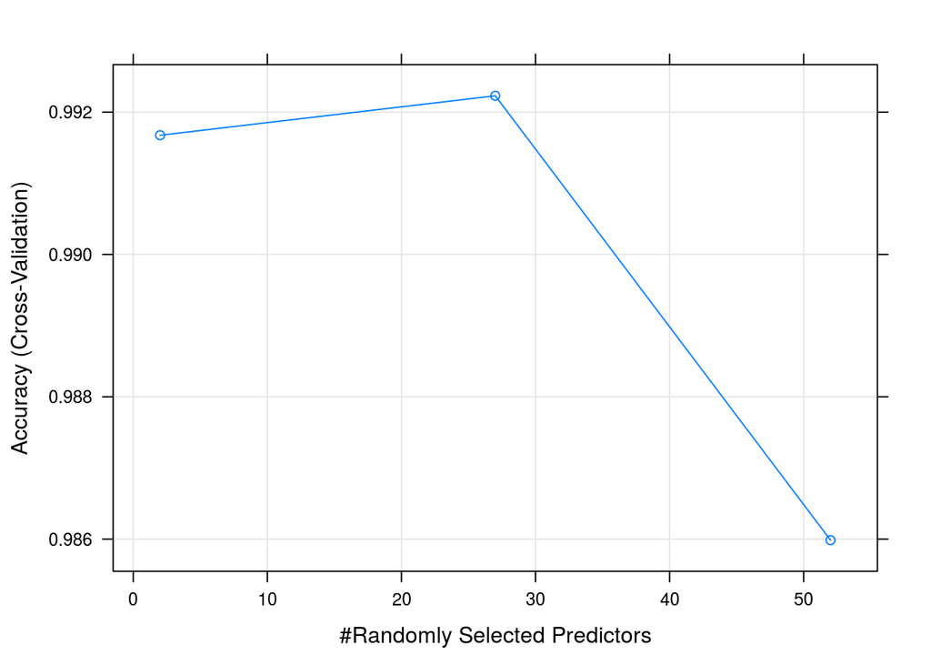

```r
plot(rfFit)
```

```r
rfPredict <- predict(rfFit, newdata = predictionTesting)
mean(rfPredict == predictionTesting$classe)
```

```
## [1] 0.9935444
```

## 5. Evaluate Test Data

Here I will evaluate *testing* data and save files for **Prediction Assignment Submission**.

```r
pml_write_files = function(x){
  n = length(x)
  for(i in 1:n){
    filename = paste0("problem_id_",i,".txt")
    write.table(
      x[i],
      file=filename,
      quote=FALSE,
      row.names=FALSE,
      col.names=FALSE
    )
  }
}

answers <- predict(rfFit, newdata = testing)
pml_write_files(answers)
```

## Conclusion

I’ve made some research to find more suitable prediction model and prepared data matrix with my predictions about *classe* in *testing* dataset.